# CV

Ling Jize

# 联系方式 CONTACT

- 手机 Mobile：1881340539*[如有急事，请优先电话联系，其他情况请勿打扰][Emergency only]
- 电子邮件 Email：sparkle28@qq.com
- 工作微信 WeChat for work：Lingjize_official

# 个人信息 PERSONAL INFORMATION

- 令纪泽 Ling Jize /男 Male/2000Birth

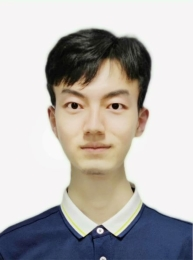

# 教育经历EDUCATION

- 2015.09~2018.06
  - 高中/西北工业大学附属中学/理科试验班/
  - High School/The Middle School Attached To Northwestern Polytechnical University (NPUMS)/Science Experimental Class/
- 2018.09~2022.06
  - 本科/北京航空航天大学 经济管理学院 经济统计学/经济学 学士/
  - Gradute/Beihang University(BUAA)/School of economics and management Economic Statistics/Bachelor of Science in Economics
  - 主修课程：微观经济学、宏观经济学、概率论、运筹学、应用统计学、应用随机过程、计量经济学、 贝叶斯统计与计算、非参数统计、时间序列分析、统计学习、大数据平台基础等。
  - Major in: Microeconomics, macroeconomics, probability theory, operational research, applied statistics, applied stochastic process, econometrics, Bayesian statistics and computing, nonparametric statistics, time series analysis, statistical learning,Big data essential etc.
- 2022.09~now
  - 硕士研究生/上海社会科学院 应用经济研究所 产业经济学（城市与房地产经济学方向）/ 应用经济学 硕士
  - Under postgraduate/Shanghai Academy of Social Sciences(SASS)/Institute of Applied Economics Industrial Economics(Urban and Real Estate Economics)/Current for Master of Science in Applied Economics

# 实习经历 INTERNSHIP EXPERIENCE

一些实习笔记参见：[sparkle28.github.io](https://sparkle28.github.io/prs/)

- **上银理财有限责任公司** 2024.07-now

  固定收益部 投研助理（暑期实习）
  - 日常投研支持工作：协助编制产品银行账户清单；协助编制银行资金动账指令单；开发自动投资指令检测分析程序；开发信托合规指标自动穿透分析程序。上述工作均使用自动化程序大大提高了日常投研效率，提高准确性，节省时间与人力劳动。
  - 研究工作：
    - 2024H1现金管理类产品规模变动研究：详细分析上半年理财市场现状，其中重点分析现金管理类产品市场现状；从宏观基本面、政策面、资金面、市场供需分析现金管理类产品上半年规模变动原因；对未来现管产品市场进行展望，对后续发展提出建议。
    - 基于机器学习方法的利率债机器久期轮动策略研究：利用利率期限结构、利差与宏观数据等预测未来周频最佳久期。
- **BOSC Wealth Management Co., Ltd.** 2024.07-now

  Fixed Income Department - Research & Investment Summer Intern
  - **Daily Investment Research Support**: Facilitated the preparation of product bank account lists and bank fund transfer instructions. Developed automated investment instruction monitoring and analysis programs, as well as automated trust compliance indicator penetration analysis tools. These automation initiatives significantly enhanced daily investment research efficiency, improved accuracy, and conserved time and labor.
  - **Research Endeavors**:
    - **2024H1 Cash Management Product Scale Variation Research**: Conducted a comprehensive analysis of the first half-year’s wealth management market, with a focus on cash management products. The study delved into macroeconomic fundamentals, policy landscapes, capital flows, and market supply-demand dynamics to explain the scale variations observed. It also offered insights into the future outlook of the cash management product market and proposed recommendations for subsequent development.
    - **Machine Learning-Based Duration Rotation Strategy Research for Interest Rate Bonds**: Leveraged machine learning methods to forecast optimal weekly durations utilizing interest rate term structures, spreads, and macroeconomic data.
- **国海证券股份有限公司** 2024.05-2024.07

  创新金融部 FOF研究岗实习生
  - **私募量化策略表现跟踪分析：** 对在投及拟投产品的业绩、策略、因子暴露等方面进行持续跟踪分析，并编制周度自动报告，以高效反映投资组合动态；参与在投项目日常监控，确保运行状态符合预期。
  - **私募基金管理人尽职调查：** 在产品纳入投资组合前，全面开展对拟投产品管理人的尽职调查工作，涵盖管理团队背景、投资策略、历史业绩、合规记录等多个维度。
  - **私募FOF投资体系研究：** 涉及资产配置优化、组合风险管理及调整策略。
  - **衍生品交易策略研究与开发：** 应用机器学习方法研究设计股指期货跨品种价差套利高频交易策略。
  - **市场观察与研究**：设计实现行业轮动指标，并进行优化；设计期权市场观察指标，并实现全自动输出日报。
- **Sealand Securities Co., Ltd.** 2024.05-2024.07

  Innovative Finance Department - FOF Research Intern
  - **Tracking and analyzing the performance of private equity quantitative strategies**: Continuously track and analyze the performance, strategies, and factor exposures of invested and potentially invested products, and compile weekly automatic reports to efficiently reflect portfolio dynamics. Meanwhile, participate in daily monitoring to ensure that the operating status of invested projects meets expectations.
  - **Due diligence on private equity fund managers**: Before incorporating products into the investment portfolio, conduct comprehensive due diligence on the managers of proposed investment products, covering multiple dimensions such as management team background, investment strategies, historical performance, and compliance records.
  - **Research on private equity FOF investment system**: Involving asset allocation optimization, portfolio risk management, and adjustment strategies.
  - **Research and development of derivative trading strategies**: Apply machine learning technology to conduct research on High-frequency Trading Strategies for Cross-species Spreads Targeting Stock Index Futures.
  - **Market Observation and Research**: Design and implement industry rotation indicators, with optimization measures in place; devise options market observation indicators, and implement fully automated daily report generation.
- **上海基煜基金销售有限公司** 2023.12-2024.03

  产品研究部 基金研究实习生
  - 协助完成基金筛选与评价工作，包括因子穿透，因子暴露计算与业绩归因；
  - 完成基金入池分析报告，内容包含基金公司情况、基金基本信息、业绩分析、持有人结构、资产配置、基金经理；
  - 协助撰写主题基金投资研报，如ESG主题研报从ESG投资理念、投资策略、市场情况、收益风险等角度分析ESG投资可⾏性；
  - 参与每周基金经理路演，完成基金经理调研报告，包含路演内容中的政策观点、市场观点、投资理念、组合框架、产品特点等；
  - 在导师指导下学习尝试FOF组合构建。
- **Shanghai Jiyu Fund Sales Co., Ltd.** 2023.12-2024.03

  Product Research Department - Fund Research Intern
  - Assisted in fund screening and evaluation, including factor penetration, factor exposure calculation, and performance attribution;
  - Completed fund analysis reports for inclusion in the fund pool, covering fund company information, basic fund details, performance analysis, holder structure, asset allocation, and fund managers;
  - Assisted in writing thematic fund investment research reports, such as ESG-themed reports analyzing the feasibility of ESG investments from the perspectives of ESG investment philosophy, investment strategy, market conditions, and risk-return profiles;
  - Participated in weekly fund manager roadshows and compiled research reports on fund managers, including policy viewpoints, market insights, investment philosophies, portfolio frameworks, and product features discussed during the roadshows;
  - Learned and attempted FOF portfolio construction under the guidance of a mentor.
- **敦和资产管理有限公司** 2023.07-2023.11

  量化投资部 量化投资助理
  - 深度参与“敦和全球宏观策略1号”量化中性对冲基金运行。
    - **交易：** 1. 优化开发自动计算策略交易数据、统计收益数据程序；2. 配套更新交易数据统计表；3. 统计每日篮子、产品收益和风险信息
    - **风控：** 1. 根据当日收益情况、产品最大回撤与其他风控规则进行风险预警和控制；2. 每日复盘风控规则并优化更新；3. 利用Wind Client API开发持仓股票跌幅自动预警程序
    - **研究：** 1. 撰写每日早报，日度更新全球宏观要闻、中美宏观数据、全球主要市场行情、持仓股票重点负面资讯；2. 利用Wind Client API开发每日资金流向（大盘主力、北向资金）分析监测程序；3. 利用Wind Client API动态复现公司策略周报，并实现自动日度更新；4. 利用Wind excel 插件制作持仓股票与沪深A股的中报内容报表，自动刷新进行跟踪与分类统计。
- **Dunhe Asset Management Co., Ltd.** 2023.07-2023.11

Quantitative Investment Department - Quantitative Investment Assistant

- Deep involvement in the operation of “Dunhe Global Macro Strategy 1” quantitative neutral hedging fund.
  - Trading: 1. Optimized the development of automatic calculation of strategic trading data and statistical income data program; 2. Updated the trading data statistics table; 3. Compiled daily basket, product income, and risk information.
  - Risk Control: 1. Conducted risk warnings and controls based on daily income, maximum product drawdown, and other risk control rules; 2. Reviewed risk control rules daily and optimized updates; 3. Developed an automatic warning program for holdings stock declines using the Wind Client API.
  - Research: 1. Wrote daily morning reports, updating global macro news, China-US macro data, global major market conditions, and key negative information on holdings stocks daily; 2. Developed daily capital flow (major market players, northbound funds) analysis and monitoring programs using the Wind Client API; 3. Dynamically reproduced the company’s weekly strategic report using the Wind Client API and achieved automatic daily updates; 4. Used the Wind Excel plugin to create a report on the mid-term reports of holdings stocks and Shanghai and Shenzhen A-shares, with automatic refresh for tracking and classified statistics.
- **国务院发展研究中心信息网** 2022.06-2023.01

  行业研究部 助理研究员
  - 独立撰写**行业月报**四篇：涉及股份制商业银行、人工智能、大数据、区块链等，调查研究当月宏观经济趋势、行业发展动态、头部企业经营状况、行业投融资状况、行业风险及行业发展前景等，送目标客户参阅。
- **Development Research Center of the State Council Net** 2022.06-2023.01

  Internship research assistant in Industry Research Department
  - Monthly Report of Industries: Wrote 4 monthly reports for client indepently,which concentrate on joint-equity commercial bank,artificial intelligence,big data, Blockchain and so on. The reports contain macroeconomic situation in the current month, development trends of each industry, business status of head enterprises, investment and financing status,risks and development prospects.
- **中碳能投科技（北京）有限公司** 2021.07-2021.08

  技术部实习研究助理/总经理实习助理
  - 碳市场调研：详细调研碳足迹计量及各国政策和碳披露标准和披露现状。
  - 某企业碳排放量及碳达峰碳中和建模预测：利用系统动力学模型对某企业未来十年的碳排放量进行仿真计算。
- **Chinacex Energy Tech. (Beijing) Co., Ltd** 2021.07-2021.08

  Internship research assistant of Technology Department & internship assistant of vice president
  - Carbon Market Research: Detailed research on carbon footprint measurement, policies and carbon disclosure standards as well as disclosure status.
  - Modeling and prediction for peak of carbon emissions and carbon neutralization of an enterprise: Simulate the carbon emission of the enterprise in next ten years by using the system dynamics model.

# 竞赛经历 COMPETITION EXPERIENCE

- **Kaggle - Optiver Trading at the Close** 2023.09-2023.12
  - [LINK HERE](https://www.kaggle.com/competitions/optiver-trading-at-the-close)
  - [View my Certificate](https://www.kaggle.com/certification/competitions/sparkle28/optiver-trading-at-the-close)

# 项目经历 PROJECT EXPERIENCE

- **黄浦区发展金融科技前沿技术及突破重点研究** 2023.03-2023.06
- Research on cutting-edge technologies and breakthroughs in the development of financial technology,Huangpu Goverment 2023.03-2023.06
- **数据要素赋能上海科创0-1科学研究** 2024.02-2024.07
- Data Elements Enable Scientific Research of Shanghai Science and Innovation from 0 to 1,Shanghai Goverment 2024.02-2024.07

[PDF Ver](https://gitee.com/sparkle28/files/raw/master/CV/%E4%BB%A4%E7%BA%AA%E6%B3%BD20240824.pdf)